# Practice Writing Functions

Author

Isabelle Antaran

#!pip install palmerpenguins

```python
import numpy as np
import pandas as pd
from sys import exit
from palmerpenguins import load_penguins
from plotnine import ggplot, aes, geom_point, geom_bar, labs
```

## In-class Activity:

```python
penguins = load_penguins()
print(penguins)
```

```
       species     island  bill_length_mm  ...  body_mass_g     sex  year
0       Adelie  Torgersen            39.1  ...       3750.0    male  2007
1       Adelie  Torgersen            39.5  ...       3800.0  female  2007
2       Adelie  Torgersen            40.3  ...       3250.0  female  2007
3       Adelie  Torgersen             NaN  ...          NaN     NaN  2007
4       Adelie  Torgersen            36.7  ...       3450.0  female  2007
..         ...        ...             ...  ...          ...     ...   ...
339  Chinstrap      Dream            55.8  ...       4000.0    male  2009
340  Chinstrap      Dream            43.5  ...       3400.0  female  2009
341  Chinstrap      Dream            49.6  ...       3775.0    male  2009
342  Chinstrap      Dream            50.8  ...       4100.0    male  2009
343  Chinstrap      Dream            50.2  ...       3775.0  female  2009

[344 rows x 8 columns]
```

```python
print(penguins.columns)
```

```
Index(['species', 'island', 'bill_length_mm', 'bill_depth_mm',
       'flipper_length_mm', 'body_mass_g', 'sex', 'year'],
      dtype='object')
```

```python
def plot_species_island(species = None, island=None):
    """
    Dynamic lookup
    """
    new_penguins = penguins

    if species is not None:
        new_penguins = new_penguins[new_penguins['species'] == species] #Filter for species

    if island is not None:
        new_penguins = new_penguins[new_penguins["island" == island]] #Filter for island

    plot = (
        ggplot(new_penguins, aes(x= "bill_length_mm", y= "bill_depth_mm", fill= "island"))
        + geom_point()
        + labs(
            title = "Scatter Plot",
            x= "bill_length", y= "bill_depth"
        )
    )

    plot.show()
```

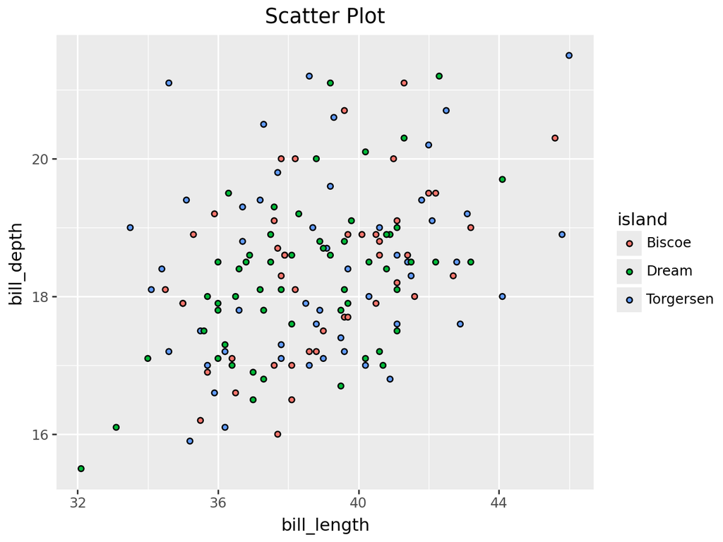

```python
plot_species_island(species= "Adelie")
```

```python
def rescale_vector(vec):
    if any(np.isnan(vec)):
        exit("Stop now")

    minimum_vec = min(vec)
    print("minimum: " + str(minimum_vec))

    maximum_vec = max(vec)
    print("maximum: " + str(maximum_vec))

    rescale = (vec - minimum_vec) / (maximum_vec - minimum_vec)

    return rescale
```

```python
#trials from lecture
my_list = [0, 1, 2, 3, 4]
new_list = np.sqrt(my_list)
print(rescale_vector(new_list))
```

```
minimum: 0.0
maximum: 2.0
[0.         0.5        0.70710678 0.8660254  1.        ]
```

```python
my_list = [-1, 0, 1,2,3,4]
new_list = np.sqrt(my_list)
print(rescale_vector(new_list))
```

```
An exception has occurred, use %tb to see the full traceback.



SystemExit: Stop now
```

## Practice Activity:

1. Fill in the necessary code to write a function called `times_seven()`. The function should take a single argument (`x`) and multiply the input by 7.
- This function should check that the argument is numeric.
- This function should also excitedly announce (print) *“I love sevens!”* if the argument to the function is a 7.

```python
def times_seven(x):

  if not isinstance(x, (int, float)):
    exit("Please enter numeric value.")

  if isinstance(x, (int, float)):
    print("I love sevens!")

  return x* 7
```

2. Write and run some *unit tests* for your `times_seven` function. What happens if the input to the function is `[1, 3, 5, 7]`?

```python
times_seven(23)
```

```
I love sevens!
```

```
161
```

```python
times_seven(7)
```

```
I love sevens!
```

```
49
```

```python
list= [1,3,5,7]
print(times_seven(list))
```

```
An exception has occurred, use %tb to see the full traceback.



SystemExit: Please enter numeric value.
```

```python
times_seven("Isabelle")
```

```
An exception has occurred, use %tb to see the full traceback.



SystemExit: Please enter numeric value.
```

```python
my_list = [1, 3, 5, 7]

for x in my_list:
    print(times_seven(x))
```

```
I love sevens!
7
I love sevens!
21
I love sevens!
35
I love sevens!
49
```

3. Consider the following function:

```python
def add_or_subtract(first_num, second_num = 2, type = "add"):

  if (type == "add"):
    res = first_num + second_num
  elif (type == "subtract"):
    res = first_num - second_num
  else:
    exit("Choose `add` or `subtract` as the type.")

    return res
```

**Without running the code**, predict if the following will produce:

1. 1
2. -1
3. 30
4. An error defined by the function `add_or_subtract()`
5. An error defined in a different function, which is called inside the `add_or_subtract()` function

```python
add_or_subtract(5, 6, type = "subtract")

add_or_subtract("orange")

add_or_subtract(5, 6, type = "multiply")
```

4. Consider the following code:

```python
first_num  = 5
second_num = 3

result = 8

result = add_or_subtract(first_num, second_num = 4)

result_2 = add_or_subtract(first_num)
```

In your Global Environment, what is the value of…

1. `first_num`
2. `second_num`
3. `result`
4. `result_2`

In my Global Environment, the value of `first_num` is 5, the value of `second_num` is 3, the output of `result` is “None, and the output of `result_2` is also None.

```python
print(first_num)
print(second_num)
print(result)
print(result_2)
```

```
5
3
None
None
```